# Risk Factor Analysis

## Outcome Variable

**Outcome Variable:** sstunted

## Predictor Variables

**Intervention Variable:** hdlvry

**Adjustment Set:**

unadjusted

## Stratifying Variables

The analysis was stratified on these variable(s):

- agecat
- studyid

The following strata were considered:

- agecat: 12 months, studyid: ki1000108-CMC-V-BCS-2002
- agecat: 12 months, studyid: ki1000108-IRC
- agecat: 12 months, studyid: ki1000109-EE
- agecat: 12 months, studyid: ki1000304b-SAS-FoodSuppl
- agecat: 12 months, studyid: ki1017093b-PROVIDE
- agecat: 12 months, studyid: ki1017093c-NIH-Crypto
- agecat: 12 months, studyid: ki1066203-TanzaniaChild2
- agecat: 12 months, studyid: ki1113344-GMS-Nepal
- agecat: 12 months, studyid: ki1135781-COHORTS
- agecat: 18 months, studyid: ki1000108-CMC-V-BCS-2002
- agecat: 18 months, studyid: ki1000108-IRC
- agecat: 18 months, studyid: ki1000109-EE
- agecat: 18 months, studyid: ki1000304b-SAS-FoodSuppl
- agecat: 18 months, studyid: ki1017093b-PROVIDE
- agecat: 18 months, studyid: ki1017093c-NIH-Crypto
- agecat: 18 months, studyid: ki1066203-TanzaniaChild2
- agecat: 18 months, studyid: ki1113344-GMS-Nepal
- agecat: 24 months, studyid: ki1000108-CMC-V-BCS-2002
- agecat: 24 months, studyid: ki1000108-IRC
- agecat: 24 months, studyid: ki1017093b-PROVIDE
- agecat: 24 months, studyid: ki1017093c-NIH-Crypto
- agecat: 24 months, studyid: ki1066203-TanzaniaChild2
- agecat: 24 months, studyid: ki1113344-GMS-Nepal
- agecat: 24 months, studyid: ki1135781-COHORTS
- agecat: 3 months, studyid: ki1000108-CMC-V-BCS-2002
- agecat: 3 months, studyid: ki1000108-IRC
- agecat: 3 months, studyid: ki1000109-EE
- agecat: 3 months, studyid: ki1000304b-SAS-FoodSuppl
- agecat: 3 months, studyid: ki1017093b-PROVIDE
- agecat: 3 months, studyid: ki1017093c-NIH-Crypto
- agecat: 3 months, studyid: ki1066203-TanzaniaChild2
- agecat: 3 months, studyid: ki1113344-GMS-Nepal
- agecat: 3 months, studyid: ki1135781-COHORTS
- agecat: 6 months, studyid: ki1000108-CMC-V-BCS-2002
- agecat: 6 months, studyid: ki1000108-IRC
- agecat: 6 months, studyid: ki1000109-EE
- agecat: 6 months, studyid: ki1000304b-SAS-FoodSuppl
- agecat: 6 months, studyid: ki1017093b-PROVIDE
- agecat: 6 months, studyid: ki1017093c-NIH-Crypto
- agecat: 6 months, studyid: ki1066203-TanzaniaChild2
- agecat: 6 months, studyid: ki1113344-GMS-Nepal
- agecat: 6 months, studyid: ki1135781-COHORTS
- agecat: 9 months, studyid: ki1000108-CMC-V-BCS-2002
- agecat: 9 months, studyid: ki1000108-IRC
- agecat: 9 months, studyid: ki1000109-EE
- agecat: 9 months, studyid: ki1000304b-SAS-FoodSuppl
- agecat: 9 months, studyid: ki1017093b-PROVIDE
- agecat: 9 months, studyid: ki1017093c-NIH-Crypto
- agecat: 9 months, studyid: ki1066203-TanzaniaChild2
- agecat: 9 months, studyid: ki1113344-GMS-Nepal
- agecat: 9 months, studyid: ki1135781-COHORTS
- agecat: Birth, studyid: ki1000108-CMC-V-BCS-2002
- agecat: Birth, studyid: ki1000108-IRC
- agecat: Birth, studyid: ki1000109-EE
- agecat: Birth, studyid: ki1017093c-NIH-Crypto
- agecat: Birth, studyid: ki1135781-COHORTS

### Dropped Strata

Some strata were dropped due to rare outcomes:

- agecat: Birth, studyid: ki1000108-CMC-V-BCS-2002
- agecat: Birth, studyid: ki1000108-IRC
- agecat: Birth, studyid: ki1000109-EE
- agecat: Birth, studyid: ki1017093c-NIH-Crypto
- agecat: 3 months, studyid: ki1000108-CMC-V-BCS-2002
- agecat: 3 months, studyid: ki1000108-IRC
- agecat: 3 months, studyid: ki1000304b-SAS-FoodSuppl
- agecat: 3 months, studyid: ki1017093b-PROVIDE
- agecat: 3 months, studyid: ki1066203-TanzaniaChild2
- agecat: 3 months, studyid: ki1113344-GMS-Nepal
- agecat: 6 months, studyid: ki1000108-CMC-V-BCS-2002
- agecat: 6 months, studyid: ki1000108-IRC
- agecat: 6 months, studyid: ki1000304b-SAS-FoodSuppl
- agecat: 6 months, studyid: ki1017093b-PROVIDE
- agecat: 6 months, studyid: ki1017093c-NIH-Crypto
- agecat: 6 months, studyid: ki1066203-TanzaniaChild2
- agecat: 6 months, studyid: ki1113344-GMS-Nepal
- agecat: 9 months, studyid: ki1000108-CMC-V-BCS-2002
- agecat: 9 months, studyid: ki1000108-IRC
- agecat: 9 months, studyid: ki1000304b-SAS-FoodSuppl
- agecat: 9 months, studyid: ki1017093b-PROVIDE
- agecat: 9 months, studyid: ki1066203-TanzaniaChild2
- agecat: 12 months, studyid: ki1000108-CMC-V-BCS-2002
- agecat: 12 months, studyid: ki1000108-IRC
- agecat: 12 months, studyid: ki1017093b-PROVIDE
- agecat: 12 months, studyid: ki1066203-TanzaniaChild2
- agecat: 18 months, studyid: ki1000108-CMC-V-BCS-2002
- agecat: 18 months, studyid: ki1000108-IRC
- agecat: 18 months, studyid: ki1066203-TanzaniaChild2
- agecat: 24 months, studyid: ki1000108-CMC-V-BCS-2002
- agecat: 24 months, studyid: ki1000108-IRC
- agecat: 24 months, studyid: ki1066203-TanzaniaChild2

## Methods Detail

We’re interested in the causal parameters $E[Y_a]$ for all values of $a \in \mathcal{A}$. These parameters represent the mean outcome if, possibly contrary to fact, we intervened to set all units to have $A=a$. Under the randomization and positivity assumptions, these are identified by the statistical parameters $\psi_a=E_W[E_{Y|A,W}(Y|A=a,W)]$. In addition, we’re interested in the mean of $Y$, $E[Y]$ under no intervention (the observed mean). We will estimate these parameters by using SuperLearner to fit the relevant likelihood factors – $E_{Y|A,W}(Y|A=a,W)$ and $p(A=a|W)$, and then updating our likelihood fit using a joint TMLE.

For unadjusted analyses ($W=\{\}$), initial likelihoods were estimated using Lrnr_glm to estimate the simple $E(Y|A)$ and Lrnr_mean to estimate $p(A)$. For adjusted analyses, a small library containing Lrnr_glmnet, Lrnr_xgboost, and Lrnr_mean was used.

Having estimated these parameters, we will then use the delta method to estimate relative risks and attributable risks relative to a prespecified baseline level of $A$.

# Results Detail

## Results Plots

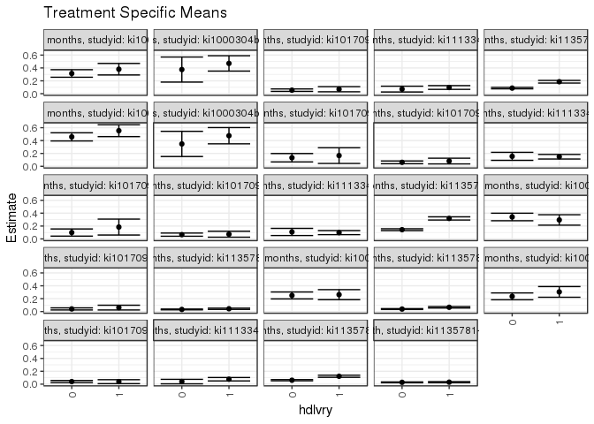

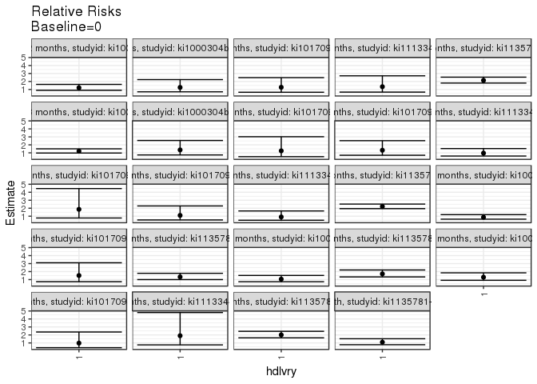

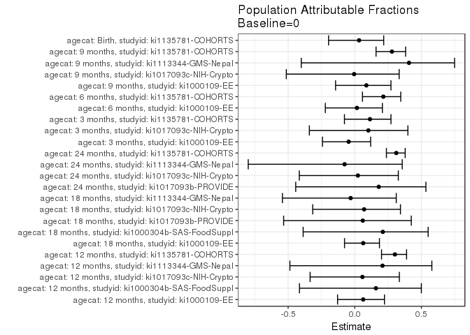

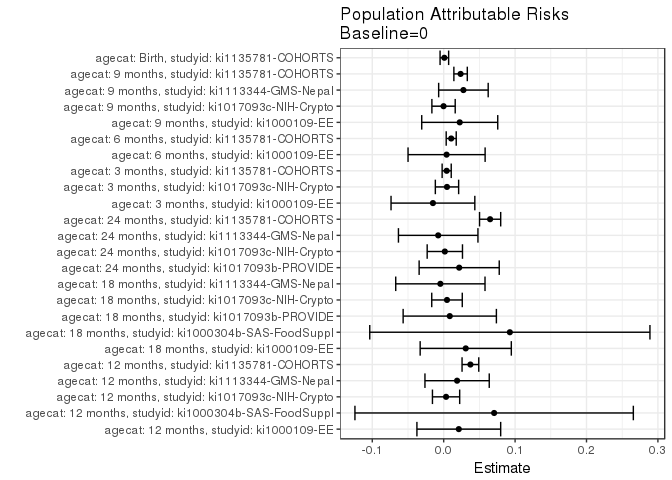

## Data Summary

| agecat | studyid | A | n | nA | nAY0 | nAY1 |
| --- | --- | --- | --- | --- | --- | --- |
| Birth | ki1000108-CMC-V-BCS-2002 | 0 | 90 | 90 | 87 | 3 |
| Birth | ki1000108-CMC-V-BCS-2002 | 1 | 90 | 0 | 0 | 0 |
| Birth | ki1000108-IRC | 0 | 388 | 381 | 365 | 16 |
| Birth | ki1000108-IRC | 1 | 388 | 7 | 7 | 0 |
| Birth | ki1000109-EE | 0 | 2 | 2 | 2 | 0 |
| Birth | ki1000109-EE | 1 | 2 | 0 | 0 | 0 |
| Birth | ki1000304b-SAS-FoodSuppl | 0 | 0 | 0 | 0 | 0 |
| Birth | ki1000304b-SAS-FoodSuppl | 1 | 0 | 0 | 0 | 0 |
| Birth | ki1017093b-PROVIDE | 0 | 0 | 0 | 0 | 0 |
| Birth | ki1017093b-PROVIDE | 1 | 0 | 0 | 0 | 0 |
| Birth | ki1017093c-NIH-Crypto | 0 | 27 | 22 | 21 | 1 |
| Birth | ki1017093c-NIH-Crypto | 1 | 27 | 5 | 5 | 0 |
| Birth | ki1066203-TanzaniaChild2 | 0 | 0 | 0 | 0 | 0 |
| Birth | ki1066203-TanzaniaChild2 | 1 | 0 | 0 | 0 | 0 |
| Birth | ki1113344-GMS-Nepal | 0 | 0 | 0 | 0 | 0 |
| Birth | ki1113344-GMS-Nepal | 1 | 0 | 0 | 0 | 0 |
| Birth | ki1135781-COHORTS | 0 | 4694 | 2938 | 2855 | 83 |
| Birth | ki1135781-COHORTS | 1 | 4694 | 1756 | 1702 | 54 |
| 3 months | ki1000108-CMC-V-BCS-2002 | 0 | 359 | 352 | 319 | 33 |
| 3 months | ki1000108-CMC-V-BCS-2002 | 1 | 359 | 7 | 7 | 0 |
| 3 months | ki1000108-IRC | 0 | 407 | 399 | 363 | 36 |
| 3 months | ki1000108-IRC | 1 | 407 | 8 | 8 | 0 |
| 3 months | ki1000109-EE | 0 | 374 | 252 | 166 | 86 |
| 3 months | ki1000109-EE | 1 | 374 | 122 | 86 | 36 |
| 3 months | ki1000304b-SAS-FoodSuppl | 0 | 97 | 24 | 21 | 3 |
| 3 months | ki1000304b-SAS-FoodSuppl | 1 | 97 | 73 | 63 | 10 |
| 3 months | ki1017093b-PROVIDE | 0 | 168 | 127 | 123 | 4 |
| 3 months | ki1017093b-PROVIDE | 1 | 168 | 41 | 40 | 1 |
| 3 months | ki1017093c-NIH-Crypto | 0 | 728 | 565 | 542 | 23 |
| 3 months | ki1017093c-NIH-Crypto | 1 | 728 | 163 | 153 | 10 |

[output cut: 96 more lines]

## Results Table

### Parameter: TSM

| agecat | studyid | intervention_level | baseline_level | estimate | ci_lower | ci_upper |
| --- | --- | --- | --- | --- | --- | --- |
| Birth | ki1135781-COHORTS | 0 | NA | 0.0282505 | 0.0222587 | 0.0342423 |
| Birth | ki1135781-COHORTS | 1 | NA | 0.0307517 | 0.0226759 | 0.0388275 |
| 3 months | ki1000109-EE | 0 | NA | 0.3412698 | 0.2826517 | 0.3998880 |
| 3 months | ki1000109-EE | 1 | NA | 0.2950820 | 0.2140437 | 0.3761202 |
| 3 months | ki1017093c-NIH-Crypto | 0 | NA | 0.0407080 | 0.0244023 | 0.0570136 |
| 3 months | ki1017093c-NIH-Crypto | 1 | NA | 0.0613497 | 0.0244850 | 0.0982144 |
| 3 months | ki1135781-COHORTS | 0 | NA | 0.0325285 | 0.0261607 | 0.0388963 |
| 3 months | ki1135781-COHORTS | 1 | NA | 0.0434084 | 0.0341617 | 0.0526551 |
| 6 months | ki1000109-EE | 0 | NA | 0.2500000 | 0.1960352 | 0.3039648 |
| 6 months | ki1000109-EE | 1 | NA | 0.2622951 | 0.1841337 | 0.3404565 |
| 6 months | ki1135781-COHORTS | 0 | NA | 0.0386207 | 0.0316069 | 0.0456345 |
| 6 months | ki1135781-COHORTS | 1 | NA | 0.0661479 | 0.0546617 | 0.0776340 |
| 9 months | ki1000109-EE | 0 | NA | 0.2357724 | 0.1826551 | 0.2888896 |
| 9 months | ki1000109-EE | 1 | NA | 0.3050847 | 0.2218929 | 0.3882766 |
| 9 months | ki1017093c-NIH-Crypto | 0 | NA | 0.0398551 | 0.0235247 | 0.0561855 |
| 9 months | ki1017093c-NIH-Crypto | 1 | NA | 0.0389610 | 0.0083780 | 0.0695441 |
| 9 months | ki1113344-GMS-Nepal | 0 | NA | 0.0403226 | 0.0056652 | 0.0749800 |
| 9 months | ki1113344-GMS-Nepal | 1 | NA | 0.0767263 | 0.0503193 | 0.1031334 |
| 9 months | ki1135781-COHORTS | 0 | NA | 0.0611354 | 0.0517784 | 0.0704923 |
| 9 months | ki1135781-COHORTS | 1 | NA | 0.1226955 | 0.1064801 | 0.1389108 |
| 12 months | ki1000109-EE | 0 | NA | 0.3140496 | 0.2554899 | 0.3726092 |
| 12 months | ki1000109-EE | 1 | NA | 0.3805310 | 0.2908859 | 0.4701760 |
| 12 months | ki1000304b-SAS-FoodSuppl | 0 | NA | 0.3750000 | 0.1802528 | 0.5697472 |
| 12 months | ki1000304b-SAS-FoodSuppl | 1 | NA | 0.4705882 | 0.3513037 | 0.5898728 |
| 12 months | ki1017093c-NIH-Crypto | 0 | NA | 0.0547445 | 0.0356851 | 0.0738040 |
| 12 months | ki1017093c-NIH-Crypto | 1 | NA | 0.0696203 | 0.0299079 | 0.1093326 |
| 12 months | ki1113344-GMS-Nepal | 0 | NA | 0.0714286 | 0.0264171 | 0.1164401 |
| 12 months | ki1113344-GMS-Nepal | 1 | NA | 0.0962025 | 0.0670957 | 0.1253094 |
| 12 months | ki1135781-COHORTS | 0 | NA | 0.0868607 | 0.0752685 | 0.0984529 |
| 12 months | ki1135781-COHORTS | 1 | NA | 0.1859114 | 0.1653606 | 0.2064622 |
| 18 months | ki1000109-EE | 0 | NA | 0.4576271 | 0.3939737 | 0.5212806 |
| 18 months | ki1000109-EE | 1 | NA | 0.5535714 | 0.4613723 | 0.6457706 |
| 18 months | ki1000304b-SAS-FoodSuppl | 0 | NA | 0.3478261 | 0.1520104 | 0.5436418 |
| 18 months | ki1000304b-SAS-FoodSuppl | 1 | NA | 0.4754098 | 0.3493351 | 0.6014845 |
| 18 months | ki1017093b-PROVIDE | 0 | NA | 0.1333333 | 0.0680812 | 0.1985854 |
| 18 months | ki1017093b-PROVIDE | 1 | NA | 0.1666667 | 0.0444934 | 0.2888399 |
| 18 months | ki1017093c-NIH-Crypto | 0 | NA | 0.0616016 | 0.0402311 | 0.0829722 |
| 18 months | ki1017093c-NIH-Crypto | 1 | NA | 0.0816327 | 0.0373359 | 0.1259295 |
| 18 months | ki1113344-GMS-Nepal | 0 | NA | 0.1550388 | 0.0925191 | 0.2175584 |
| 18 months | ki1113344-GMS-Nepal | 1 | NA | 0.1488251 | 0.1131454 | 0.1845047 |
| 24 months | ki1017093b-PROVIDE | 0 | NA | 0.0990991 | 0.0433263 | 0.1548719 |
| 24 months | ki1017093b-PROVIDE | 1 | NA | 0.1842105 | 0.0605404 | 0.3078807 |
| 24 months | ki1017093c-NIH-Crypto | 0 | NA | 0.0664962 | 0.0417767 | 0.0912156 |
| 24 months | ki1017093c-NIH-Crypto | 1 | NA | 0.0731707 | 0.0271040 | 0.1192374 |
| 24 months | ki1113344-GMS-Nepal | 0 | NA | 0.1083333 | 0.0526654 | 0.1640013 |
| 24 months | ki1113344-GMS-Nepal | 1 | NA | 0.0979827 | 0.0666693 | 0.1292962 |
| 24 months | ki1135781-COHORTS | 0 | NA | 0.1437528 | 0.1291991 | 0.1583065 |
| 24 months | ki1135781-COHORTS | 1 | NA | 0.3182504 | 0.2931758 | 0.3433250 |

### Parameter: E(Y)

| agecat | studyid | intervention_level | baseline_level | estimate | ci_lower | ci_upper |
| --- | --- | --- | --- | --- | --- | --- |
| Birth | ki1135781-COHORTS | NA | NA | 0.0291862 | 0.0291516 | 0.0292208 |
| 3 months | ki1000109-EE | NA | NA | 0.3262032 | 0.3240057 | 0.3284007 |
| 3 months | ki1017093c-NIH-Crypto | NA | NA | 0.0453297 | 0.0447042 | 0.0459552 |
| 3 months | ki1135781-COHORTS | NA | NA | 0.0367162 | 0.0365671 | 0.0368652 |
| 6 months | ki1000109-EE | NA | NA | 0.2540541 | 0.2534643 | 0.2546438 |
| 6 months | ki1135781-COHORTS | NA | NA | 0.0491594 | 0.0487768 | 0.0495420 |
| 9 months | ki1000109-EE | NA | NA | 0.2582418 | 0.2549043 | 0.2615792 |
| 9 months | ki1017093c-NIH-Crypto | NA | NA | 0.0396601 | 0.0396328 | 0.0396873 |
| 9 months | ki1113344-GMS-Nepal | NA | NA | 0.0679612 | 0.0666156 | 0.0693067 |
| 9 months | ki1135781-COHORTS | NA | NA | 0.0847996 | 0.0838820 | 0.0857173 |
| 12 months | ki1000109-EE | NA | NA | 0.3352113 | 0.3319853 | 0.3384373 |
| 12 months | ki1000304b-SAS-FoodSuppl | NA | NA | 0.4456522 | 0.4370283 | 0.4542761 |
| 12 months | ki1017093c-NIH-Crypto | NA | NA | 0.0580737 | 0.0576160 | 0.0585313 |
| 12 months | ki1113344-GMS-Nepal | NA | NA | 0.0902111 | 0.0892994 | 0.0911229 |
| 12 months | ki1135781-COHORTS | NA | NA | 0.1242798 | 0.1227206 | 0.1258391 |
| 18 months | ki1000109-EE | NA | NA | 0.4885057 | 0.4837896 | 0.4932219 |
| 18 months | ki1000304b-SAS-FoodSuppl | NA | NA | 0.4404762 | 0.4282370 | 0.4527154 |
| 18 months | ki1017093b-PROVIDE | NA | NA | 0.1418440 | 0.1394363 | 0.1442516 |
| 18 months | ki1017093c-NIH-Crypto | NA | NA | 0.0662461 | 0.0655875 | 0.0669046 |
| 18 months | ki1113344-GMS-Nepal | NA | NA | 0.1503906 | 0.1501567 | 0.1506245 |
| 24 months | ki1017093b-PROVIDE | NA | NA | 0.1208054 | 0.1148285 | 0.1267822 |
| 24 months | ki1017093c-NIH-Crypto | NA | NA | 0.0680934 | 0.0678470 | 0.0683398 |
| 24 months | ki1113344-GMS-Nepal | NA | NA | 0.1006424 | 0.1002318 | 0.1010530 |
| 24 months | ki1135781-COHORTS | NA | NA | 0.2087665 | 0.2059943 | 0.2115387 |

### Parameter: RR

| agecat | studyid | intervention_level | baseline_level | estimate | ci_lower | ci_upper |
| --- | --- | --- | --- | --- | --- | --- |
| Birth | ki1135781-COHORTS | 1 | 0 | 1.0885364 | 0.7766770 | 1.525617 |
| 3 months | ki1000109-EE | 1 | 0 | 0.8646588 | 0.6254143 | 1.195423 |
| 3 months | ki1017093c-NIH-Crypto | 1 | 0 | 1.5070686 | 0.7319858 | 3.102869 |
| 3 months | ki1135781-COHORTS | 1 | 0 | 1.3344714 | 0.9992287 | 1.782189 |
| 6 months | ki1000109-EE | 1 | 0 | 1.0491803 | 0.7261859 | 1.515837 |
| 6 months | ki1135781-COHORTS | 1 | 0 | 1.7127571 | 1.3322122 | 2.202004 |
| 9 months | ki1000109-EE | 1 | 0 | 1.2939801 | 0.9084734 | 1.843075 |
| 9 months | ki1017093c-NIH-Crypto | 1 | 0 | 0.9775679 | 0.4032655 | 2.369752 |
| 9 months | ki1113344-GMS-Nepal | 1 | 0 | 1.9028131 | 0.7538832 | 4.802730 |
| 9 months | ki1135781-COHORTS | 1 | 0 | 2.0069476 | 1.6395124 | 2.456730 |
| 12 months | ki1000109-EE | 1 | 0 | 1.2116907 | 0.8972435 | 1.636339 |
| 12 months | ki1000304b-SAS-FoodSuppl | 1 | 0 | 1.2549020 | 0.7041050 | 2.236569 |
| 12 months | ki1017093c-NIH-Crypto | 1 | 0 | 1.2717300 | 0.6518834 | 2.480961 |
| 12 months | ki1113344-GMS-Nepal | 1 | 0 | 1.3468354 | 0.6694669 | 2.709567 |
| 12 months | ki1135781-COHORTS | 1 | 0 | 2.1403404 | 1.7997946 | 2.545322 |
| 18 months | ki1000109-EE | 1 | 0 | 1.2096561 | 0.9736923 | 1.502803 |
| 18 months | ki1000304b-SAS-FoodSuppl | 1 | 0 | 1.3668033 | 0.7335723 | 2.546649 |
| 18 months | ki1017093b-PROVIDE | 1 | 0 | 1.2500000 | 0.5177579 | 3.017819 |
| 18 months | ki1017093c-NIH-Crypto | 1 | 0 | 1.3251701 | 0.6959259 | 2.523366 |
| 18 months | ki1113344-GMS-Nepal | 1 | 0 | 0.9599217 | 0.6004721 | 1.534542 |
| 24 months | ki1017093b-PROVIDE | 1 | 0 | 1.8588516 | 0.7740751 | 4.463817 |
| 24 months | ki1017093c-NIH-Crypto | 1 | 0 | 1.1003752 | 0.5296782 | 2.285965 |
| 24 months | ki1113344-GMS-Nepal | 1 | 0 | 0.9044558 | 0.4938359 | 1.656502 |
| 24 months | ki1135781-COHORTS | 1 | 0 | 2.2138726 | 1.9473253 | 2.516904 |

### Parameter: PAR

| agecat | studyid | intervention_level | baseline_level | estimate | ci_lower | ci_upper |
| --- | --- | --- | --- | --- | --- | --- |
| Birth | ki1135781-COHORTS | 0 | NA | 0.0009357 | -0.0050562 | 0.0069276 |
| 3 months | ki1000109-EE | 0 | NA | -0.0150666 | -0.0737259 | 0.0435927 |
| 3 months | ki1017093c-NIH-Crypto | 0 | NA | 0.0046217 | -0.0116959 | 0.0209393 |
| 3 months | ki1135781-COHORTS | 0 | NA | 0.0041877 | -0.0021819 | 0.0105572 |
| 6 months | ki1000109-EE | 0 | NA | 0.0040541 | -0.0499140 | 0.0580221 |
| 6 months | ki1135781-COHORTS | 0 | NA | 0.0105387 | 0.0035145 | 0.0175629 |
| 9 months | ki1000109-EE | 0 | NA | 0.0224694 | -0.0307526 | 0.0756914 |
| 9 months | ki1017093c-NIH-Crypto | 0 | NA | -0.0001950 | -0.0165254 | 0.0161354 |
| 9 months | ki1113344-GMS-Nepal | 0 | NA | 0.0276386 | -0.0070449 | 0.0623221 |
| 9 months | ki1135781-COHORTS | 0 | NA | 0.0236642 | 0.0142624 | 0.0330661 |
| 12 months | ki1000109-EE | 0 | NA | 0.0211617 | -0.0374868 | 0.0798101 |
| 12 months | ki1000304b-SAS-FoodSuppl | 0 | NA | 0.0706522 | -0.1242859 | 0.2655903 |
| 12 months | ki1017093c-NIH-Crypto | 0 | NA | 0.0033291 | -0.0157358 | 0.0223941 |
| 12 months | ki1113344-GMS-Nepal | 0 | NA | 0.0187826 | -0.0262382 | 0.0638033 |
| 12 months | ki1135781-COHORTS | 0 | NA | 0.0374192 | 0.0257226 | 0.0491158 |
| 18 months | ki1000109-EE | 0 | NA | 0.0308786 | -0.0329493 | 0.0947065 |
| 18 months | ki1000304b-SAS-FoodSuppl | 0 | NA | 0.0926501 | -0.1035477 | 0.2888480 |
| 18 months | ki1017093b-PROVIDE | 0 | NA | 0.0085106 | -0.0567858 | 0.0738071 |
| 18 months | ki1017093c-NIH-Crypto | 0 | NA | 0.0046444 | -0.0167363 | 0.0260251 |
| 18 months | ki1113344-GMS-Nepal | 0 | NA | -0.0046481 | -0.0671682 | 0.0578719 |
| 24 months | ki1017093b-PROVIDE | 0 | NA | 0.0217063 | -0.0343858 | 0.0777984 |
| 24 months | ki1017093c-NIH-Crypto | 0 | NA | 0.0015972 | -0.0231235 | 0.0263179 |
| 24 months | ki1113344-GMS-Nepal | 0 | NA | -0.0076909 | -0.0633604 | 0.0479785 |
| 24 months | ki1135781-COHORTS | 0 | NA | 0.0650137 | 0.0501984 | 0.0798290 |

### Parameter: PAF

| agecat | studyid | intervention_level | baseline_level | estimate | ci_lower | ci_upper |
| --- | --- | --- | --- | --- | --- | --- |
| Birth | ki1135781-COHORTS | 0 | NA | 0.0320591 | -0.1966369 | 0.2170478 |
| 3 months | ki1000109-EE | 0 | NA | -0.0461879 | -0.2424059 | 0.1190407 |
| 3 months | ki1017093c-NIH-Crypto | 0 | NA | 0.1019576 | -0.3407790 | 0.3984989 |
| 3 months | ki1135781-COHORTS | 0 | NA | 0.1140551 | -0.0775635 | 0.2715990 |
| 6 months | ki1000109-EE | 0 | NA | 0.0159574 | -0.2211408 | 0.2070204 |
| 6 months | ki1135781-COHORTS | 0 | NA | 0.2143783 | 0.0577702 | 0.3449565 |
| 9 months | ki1000109-EE | 0 | NA | 0.0870092 | -0.1441150 | 0.2714436 |
| 9 months | ki1017093c-NIH-Crypto | 0 | NA | -0.0049172 | -0.5138408 | 0.3329163 |
| 9 months | ki1113344-GMS-Nepal | 0 | NA | 0.4066820 | -0.4017297 | 0.7488629 |
| 9 months | ki1135781-COHORTS | 0 | NA | 0.2790607 | 0.1595057 | 0.3816098 |
| 12 months | ki1000109-EE | 0 | NA | 0.0631294 | -0.1291943 | 0.2226966 |
| 12 months | ki1000304b-SAS-FoodSuppl | 0 | NA | 0.1585366 | -0.4149209 | 0.4995758 |
| 12 months | ki1017093c-NIH-Crypto | 0 | NA | 0.0573260 | -0.3353684 | 0.3345400 |
| 12 months | ki1113344-GMS-Nepal | 0 | NA | 0.2082067 | -0.4870397 | 0.5783995 |
| 12 months | ki1135781-COHORTS | 0 | NA | 0.3010880 | 0.2008323 | 0.3887666 |
| 18 months | ki1000109-EE | 0 | NA | 0.0632104 | -0.0769496 | 0.1851292 |
| 18 months | ki1000304b-SAS-FoodSuppl | 0 | NA | 0.2103408 | -0.3874974 | 0.5505853 |
| 18 months | ki1017093b-PROVIDE | 0 | NA | 0.0600000 | -0.5338939 | 0.4239497 |
| 18 months | ki1017093c-NIH-Crypto | 0 | NA | 0.0701085 | -0.3157023 | 0.3427859 |
| 18 months | ki1113344-GMS-Nepal | 0 | NA | -0.0309071 | -0.5429460 | 0.3112077 |
| 24 months | ki1017093b-PROVIDE | 0 | NA | 0.1796797 | -0.4432652 | 0.5337479 |
| 24 months | ki1017093c-NIH-Crypto | 0 | NA | 0.0234563 | -0.4162668 | 0.3266541 |
| 24 months | ki1113344-GMS-Nepal | 0 | NA | -0.0764184 | -0.7995084 | 0.3561149 |
| 24 months | ki1135781-COHORTS | 0 | NA | 0.3114183 | 0.2373936 | 0.3782576 |